# Chapter 3 Answers

#### Problem 3.4

```r
result3.4.a <- prob_norm(mean = 61000, stdev = 9000, ub = 50000, dec = 10)
summary(result3.4.a)
```

```
## Probability calculator
## Distribution: Normal
## Mean        : 61000
## St. dev     : 9000
## Lower bound : -Inf
## Upper bound : 50000
##
## P(X < 50000) = 0.1108118012
## P(X > 50000) = 0.8891881988
```

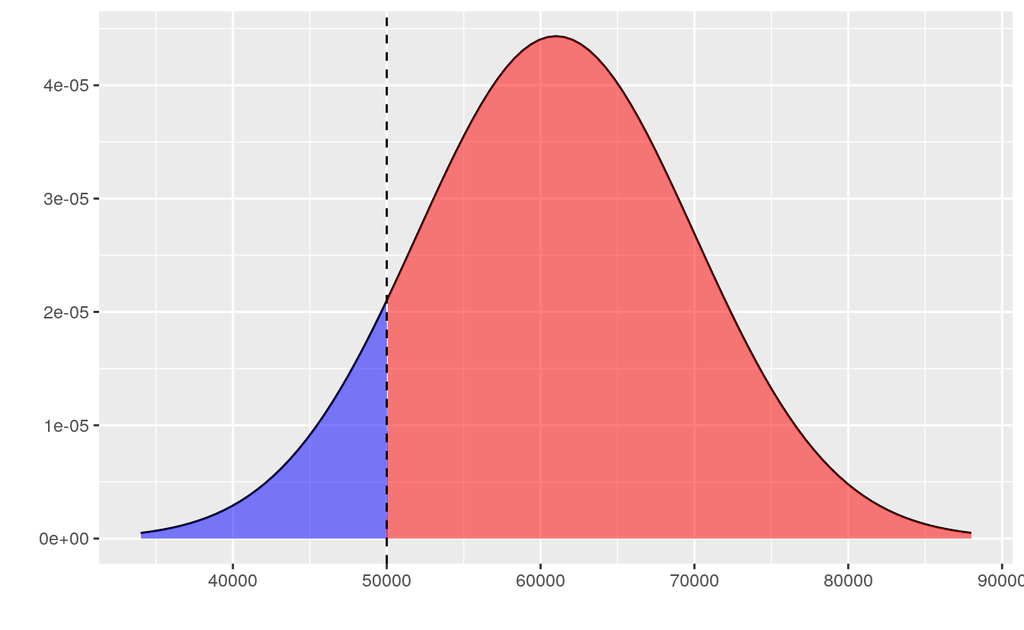

```r
plot(result3.4.a)
```

```r
result3.4.b <- prob_norm(
  mean = 61000,
  stdev = 9000,
  lb = 50000,
  ub = 50000,
  dec = 20
)
summary(result3.4.b)
```

```
## Probability calculator
## Distribution: Normal
## Mean        : 61000
## St. dev     : 9000
## Lower bound : 50000
## Upper bound : 50000
##
## P(X < 50000) = 0.110811801229697
## P(X > 50000) = 0.889188198770303
## P(X < 50000) = 0.110811801229697
## P(X > 50000) = 0.889188198770303
## P(50000 < X < 50000)     = 0
## 1 - P(50000 < X < 50000) = 1
```

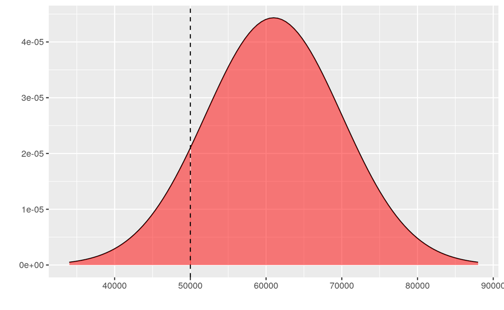

```r
plot(result3.4.b)
```

```r
result3.4.c <- prob_norm(
  mean = 61000,
  stdev = 9000,
  lb = 42000,
  ub = 57000,
  dec = 10
)
summary(result3.4.c)
```

```
## Probability calculator
## Distribution: Normal
## Mean        : 61000
## St. dev     : 9000
## Lower bound : 42000
## Upper bound : 57000
##
## P(X < 42000) = 0.0173813813
## P(X > 42000) = 0.9826186187
## P(X < 57000) = 0.3283606433
## P(X > 57000) = 0.6716393567
## P(42000 < X < 57000)     = 0.310979262
## 1 - P(42000 < X < 57000) = 0.689020738
```

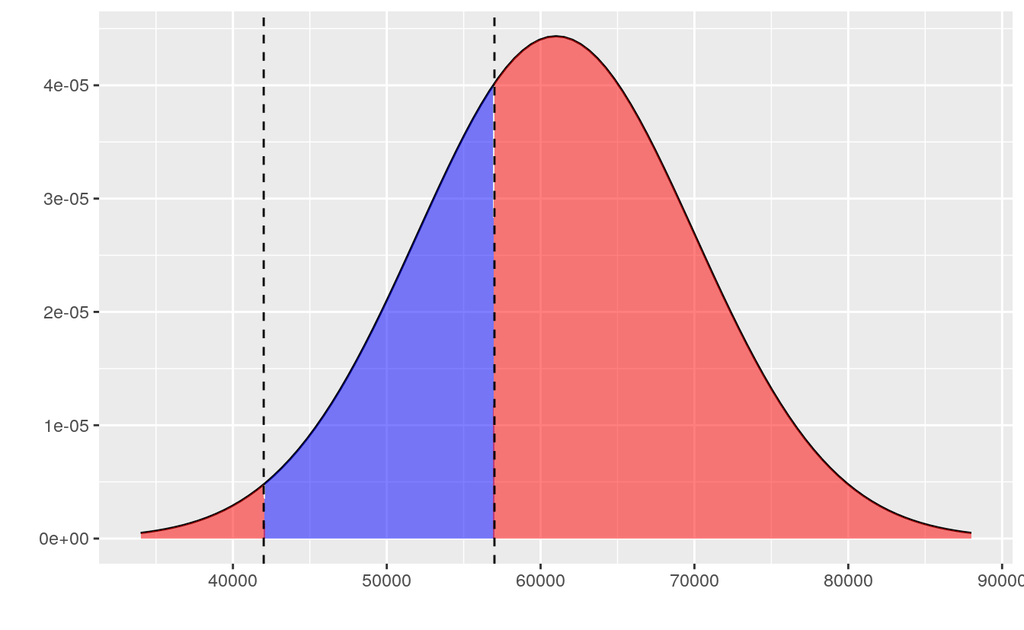

```r
plot(result3.4.c)
```

```r
result3.4.d <- prob_norm(
  mean = 61000,
  stdev = 9000,
  pub = 0.8,
  dec = 10
)
summary(result3.4.d, type = "probs")
```

```
## Probability calculator
## Distribution: Normal
## Mean        : 61000
## St. dev     : 9000
## Lower bound : 0
## Upper bound : 0.8
##
## P(X < 68574.5911021562) = 0.8
## P(X > 68574.5911021562) = 0.2
```

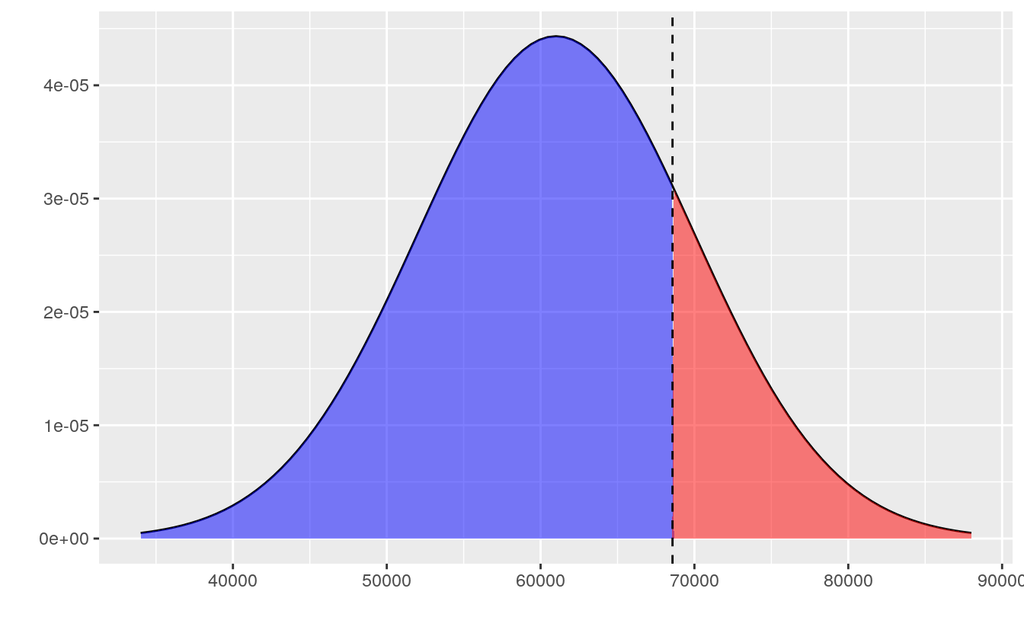

```
## [1] "Answer (a) is: "
```

```
## [1] 0.1108118
```

```
## [1] "Answer (b) is: "
```

```
## [1] 0
```

```
## [1] "Answer (c) is: "
```

```
## [1] 0.3109793
```

```
## [1] "Answer (d) is: "
```

```
## [1] 68574.59
```

```r
plot(result3.4.d, type = "probs")
```

#### Problem 3.6

```r
result3.6.a <- prob_norm(mean = 32.5, stdev = 1.59, lb = 32, dec = 10)
summary(result3.6.a)
```

```
## Probability calculator
## Distribution: Normal
## Mean        : 32.5
## St. dev     : 1.59
## Lower bound : 32
## Upper bound : Inf
##
## P(X < 32) = 0.3765837923
## P(X > 32) = 0.6234162077
```

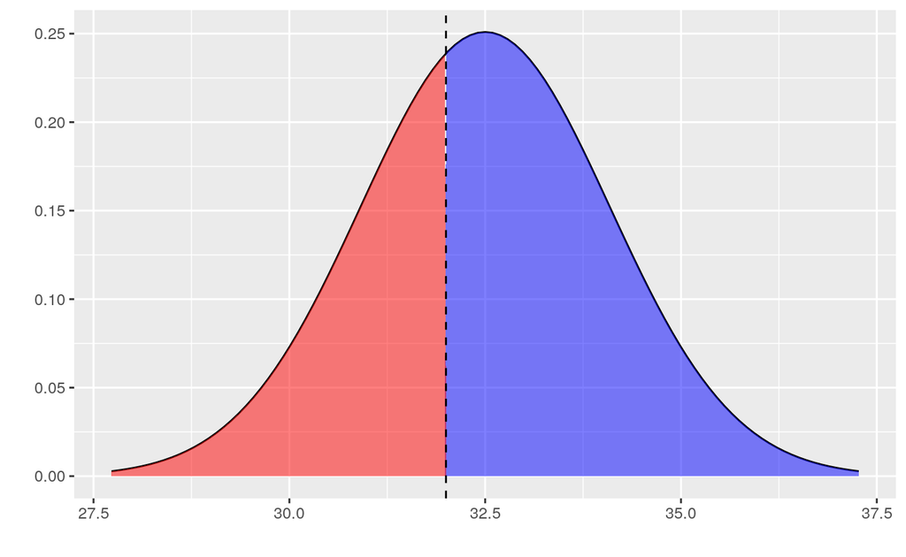

```r
plot(result3.6.a)
```

```r
#Constuct a new distribution named average winter temperature difference between Boston and NY

Bos_mean <- 32.5
NY_mean <- 35.4
new_mean <- Bos_mean - NY_mean
new_mean
```

```
## [1] -2.9
```

```r
Bos_sd <- 1.59
NY_sd <- 2.05
new_sd <- sqrt(square(Bos_sd) + square(NY_sd))
new_sd
```

```
## [1] 2.59434
```

```r
result3.6.b <- prob_norm(mean = new_mean, stdev = new_sd, lb = 0, dec = 10)
summary(result3.6.b)
```

```
## Probability calculator
## Distribution: Normal
## Mean        : -2.9
## St. dev     : 2.59434
## Lower bound : 0
## Upper bound : Inf
##
## P(X < 0) = 0.8681776386
## P(X > 0) = 0.1318223614
```

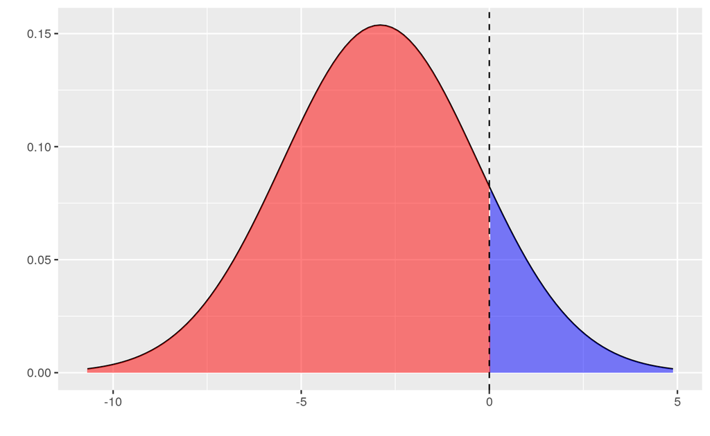

```
## [1] "Answer (a) is: "
```

```
## [1] 0.6234162
```

```
## [1] "Answer (b) is: "
```

```
## [1] 0.1318224
```

```r
plot(result3.6.b)
```

*(c)*

I think the independence assumption is not reasonable because the temperature of Boston and NY will be affected by certain weather conditions at the same time since they are both located on the east coast of the US.

#### Problem 3.10

```r
# your analysis here
n = 100
p_female = 0.522
mean_boston_female <- 100 * p_female
mean_boston_female
```

```
## [1] 52.2
```

```r
sd_boston_female <- sqrt(n*p_female*(1-p_female))
sd_boston_female
```

```
## [1] 4.995158
```

```r
result3.10.b <- prob_norm(mean = mean_boston_female, stdev = sd_boston_female, ub = 50, dec = 10)
summary(result3.10.b)
```

```
## Probability calculator
## Distribution: Normal
## Mean        : 52.2
## St. dev     : 4.995158
## Lower bound : -Inf
## Upper bound : 50
##
## P(X < 50) = 0.3298141034
## P(X > 50) = 0.6701858966
```

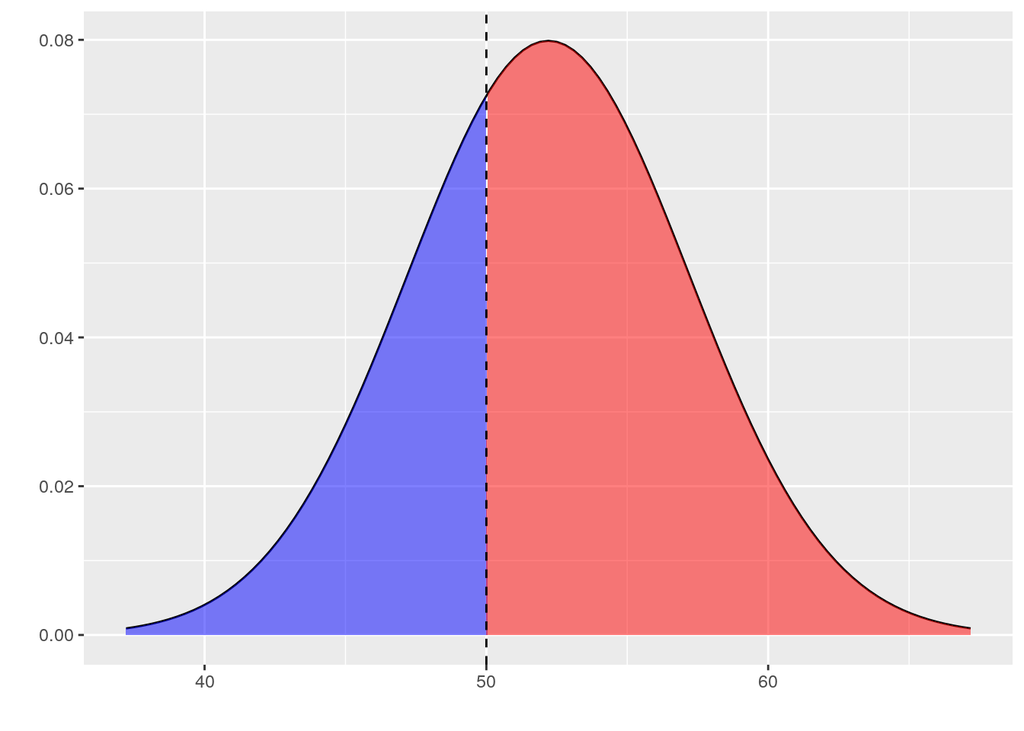

```r
plot(result3.10.b)
```

```r
result3.10.c <- prob_norm(
  mean = 52.2,
  stdev = 4.995,
  lb = 45,
  ub = 55,
  dec = 10
)
summary(result3.10.c)
```

```
## Probability calculator
## Distribution: Normal
## Mean        : 52.2
## St. dev     : 4.995
## Lower bound : 45
## Upper bound : 55
##
## P(X < 45) = 0.0747300048
## P(X > 45) = 0.9252699952
## P(X < 55) = 0.712451428
## P(X > 55) = 0.287548572
## P(45 < X < 55)     = 0.6377214231
## 1 - P(45 < X < 55) = 0.3622785769
```

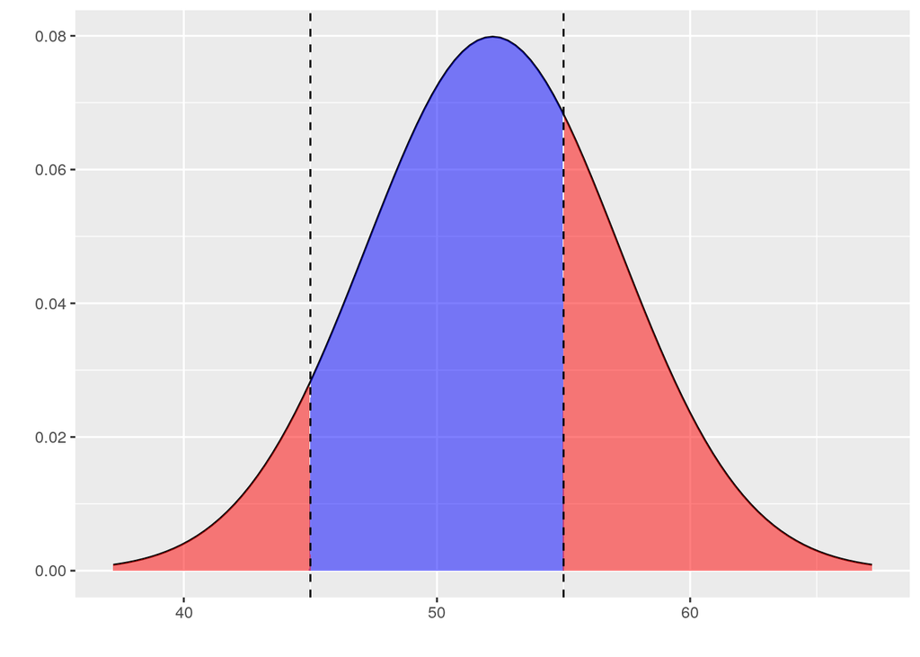

```
## [1] "Answer (a) is:"
```

```
## [1] 52.2
```

```
## [1] 4.995158
```

```
## [1] "Answer (b) is: "
```

```
## [1] 0.3298141
```

```
## [1] "Answer (c) is: "
```

```
## [1] 0.6377214
```

```r
plot(result3.10.c)
```

#### Problem 3.18

*(a)*

The assumptions I must make are 1. Each car results in having a problem or not having a problem 2. cars’ test results on electrical wiring are independent of each other 3. Cars have the same probability of having a problem

```r
result3.18.b <- prob_binom(n = 2000, p = 0.3, lb = 5, dec = 10)
summary(result3.18.b)
```

```
## Probability calculator
## Distribution: Binomial
## n           : 2000
## p           : 0.3
## Mean        : 600
## St. dev     : 20.4939
## Lower bound : 5
## Upper bound :
##
## P(X  = 5) = 0
## P(X  < 5) = 0
## P(X <= 5) = 0
## P(X  > 5) = 1
## P(X >= 5) = 1
```

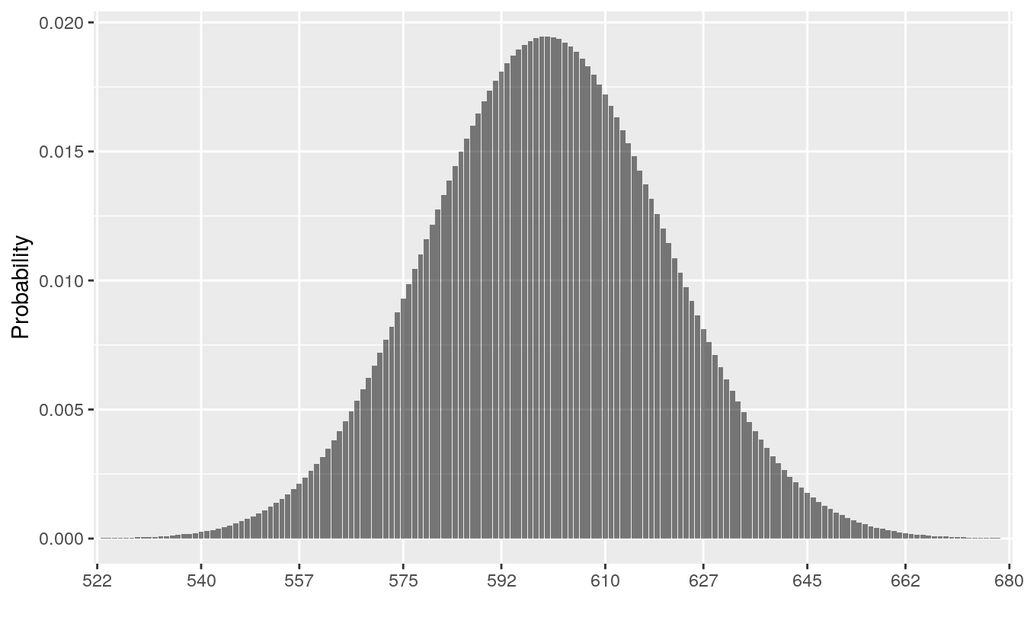

```
## [1] "Answer (b) is: "
```

```
## [1] 0
```

```r
plot(result3.18.b)
```

*(c)*

Is it likely?

No. It’s extremely unlikely that 30% of the cars have a problem because the probability of finding five or fewer cars having a problem in the given situation is almost 0%.